# hw2_BorodulinaAlena

### Выполнила: Бородулина Алена

```python
import pandas as pd
import numpy as np
import matplotlib.pyplot as plt
import random
```

## №1

### а)

$L = n/n * (n-1)/n * (n-2)/n * ... * (n-8)/n * 9/n = \\ \frac{n(n-1)(n-2)(n-3)(n-4)(n-5)(n-6)(n-7)(n-8)*9}{n^{10}}$

```python
p_l = []
for n in range(10,500):
    p = (n*(n-1)*(n-2)*(n-3)*(n-4)*(n-5)*(n-6)*(n-7)*(n-8)*9)/(n**10)
    p_l.append(p)
```

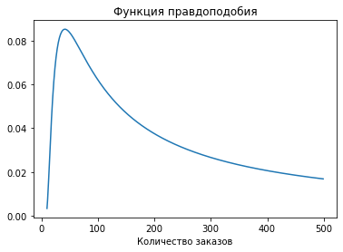

```python
plt.plot(range(10,500), p_l)
plt.xlabel('Количество заказов')
plt.title('Функция правдоподобия')
plt.show()
```

$l = ln(n) + ln(n-1) + ... + ln(n-8) + ln(9) - 10ln(n)\\ l`n = \frac{1}{n} + ... + \frac{1}{n-8} - \frac{10}{n}\\ n = 10n(n-1)(n-2)...(n-8)\\ n = 42\\ l`` < 0$

Учитывая, что водителей хотя бы 9, получим, что максимум достигается при 42.

б) Начальный выборочный момент 1 порядка: $ \sum_{i=1}^{\infty} i\frac{(i-1)n(n-1)(n-2)...(n-i+2)}{n^i} = \overline{X}$ , где справа стоит выборочный начальный момент 1 порядка (средняя), i - номер заказа, на котором происходит повтор. Выразив n через X средний получим оценку n методом моментов.

```python
import math
x_exp = []
for n in range(2, 500):
    x_pr = []
    for i in range(2, n):
        x = math.prod(range(n - i + 2, n + 1))/n**i
        x_mn = x*i*(i-1)
        x_pr.append(x_mn)
    x = sum(x_pr)
    x_exp.append(x)
```

График математического ожидания номера заказа, на котором происходит первый повторный приезд.

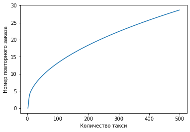

```python
plt.plot(range(2,500), x_exp)
plt.xlabel('Количество такси')
plt.ylabel('Номер повторного заказа')
plt.show()
```

в)

```python
# Сделаем выборку номеров повторных заказов
n = 100
been = []
zak = []

for i in range(10**4):
    num = 0
    for i in range(100):
        choice = random.choice(range(100))
        if choice in been:
            num += 1
            zak.append(num)
            break
        else:
            num += 1
            been.append(choice)
    been = []
```

Метод максимального правдоподобия: $П_{i=1}^{\infty} \frac{(i-1)n(n-1)(n-2)...(n-i+2)}{n^i} → max_n$

Ищу значения n "в лоб": по каждому заказу прогоняю функцию правдоподобия и ищу значение n, при котором функция достигает максимума.

```python
mmax = []
# Не повторять в домашних условиях, очень долго
for i in zak:
    df = pd.DataFrame({'mm':[0],'n': [0]})
    for n in range(2, 300):
        x = math.prod(range(n - i + 2, n + 1))/n**i
        x = x*(i-1)
        df = df.append({'mm':x,'n': n}, ignore_index=True)
    mmax.append(df[df['mm'] == max(df['mm'])]['n'].values[0])
```

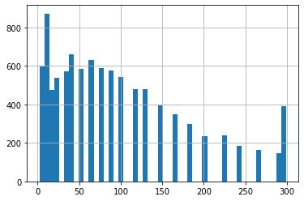

```python
df.mmax.hist(bins = 50) # Гистограмма распределения
```

```python
var = sum((df.mmax - 100)**2)/len(df.zak)
std = np.sqrt(var)
sm = sum((df.mmax - df.zak)**2)/len(df.zak) # Находим дисперсию реальных значений заказов и полученных методом

print(f'Стандартное отклонение метода максимального правдоподобия: {std}', "\n",
     f'Дисперсия: {var}', "\n",
     f'Смещение: {sm}')
```

```
Стандартное отклонение метода максимального правдоподобия: 81.72358778223091
 Дисперсия: 6678.7448
 Смещение: 12097.3062
```

## №2

а) $L = 210\frac{n}{n}*\frac{n-1}{n}*\frac{n-2}{n}*\frac{n-3}{n}*\frac{n-4}{n}*\frac{n-5}{n}*\frac{4}{n}\\ l`n = \frac{1}{n} + ... + \frac{1}{n-5} - \frac{10}{n}\\ n = 10n(n-1)(n-2)...(n-5)\\ n = 8\\ l`` < 0$ Учитывая, что водителей хотя бы 6, получим, что максимум достигается при 8

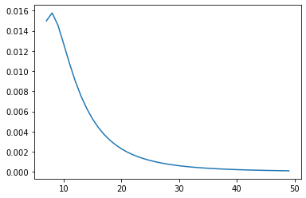

```python
p_l = []
for n in range(7,50):
    p = (210*n*(n-1)*(n-2)*(n-3)*(n-4)*(n-5)*4)/(n**10)
    p_l.append(p)
plt.plot(range(7,50), p_l)
plt.show()
```

## №4

### а) Тест Уэлча

```python
df1 = pd.read_csv('Downloads/22-23_hse_probability - Exam.csv', sep=',')
df2 = pd.DataFrame()
df2['Fam'] = df1['Last name']
df2['Exam'] = df1['Unnamed: 72']

df2 = df2.dropna()

letter = []
gl = ['а', 'е', 'ё', 'и', 'о', 'у', 'ы', 'э', 'ю', 'я']
for fam in df2['Fam']:
    if list(fam)[0].lower() in gl:
        letter.append(0)
    else:
        letter.append(1)
df2['Glasn'] = letter
df2['Median'] = np.where(df2['Exam'] > df2['Exam'].median(), 1, 0)
df2.head()
```

|  | Fam | Exam | Glasn | Median |
| --- | --- | --- | --- | --- |
| 5 | Репенкова | 16.0 | 1 | 0 |
| 6 | Ролдугина | 0.0 | 1 | 0 |
| 7 | Сафина | 19.0 | 1 | 1 |
| 8 | Сидоров | 26.0 | 1 | 1 |
| 9 | Солоухин | 21.0 | 1 | 1 |

```python
ex_gl = df2[df2['Glasn'] == 1]['Exam']
ex_sogl = df2[df2['Glasn'] == 0]['Exam']
from scipy import stats

# Рассчитаем t-статистику и p-value
st = stats.ttest_ind(ex_gl, ex_sogl, equal_var = False)

print("\n",
      f"Welch's t-test = {st[0]}", "\n",
      f"p-value = {st[1]}", "\n")
```

```
 Welch's t-test = 0.8519661870595602
 p-value = 0.3974027153843839
```

p-value > 0.05, значит, гипотеза не отвергается.

### б) Наивный бутстрэп

```python
def get_bootstrap_sample(x, B_sample=1):
    np.random.seed(122)
    N = x.size
    sample = np.random.choice(x, size=(N, B_sample), replace=True)
    return sample

# Генерируем выборки и находим их медианы
x_boot = get_bootstrap_sample(ex_gl, B_sample=10**4)
x_med = np.median(x_boot, axis=0)

y_boot = get_bootstrap_sample(ex_sogl, B_sample=10**4)
y_med = np.median(y_boot, axis=0)

# Рассчитаем статистику и p-value
st = stats.ttest_ind(x_med, y_med, equal_var = False)

print("\n",
      f"Welch's t-test = {st[0]}", "\n",
      f"p-value = {st[1]}", "\n")
```

```
 Welch's t-test = 78.57130869265276
 p-value = 0.0
```

p-value < 0.05, значит, гипотеза отвергается

### в) Бутстрэп t-статистики

```python
t_st = stats.ttest_ind(x_boot, y_boot, equal_var = False) [0]

left_t = pd.Series(t_st).quantile(0.025)
right_t = pd.Series(t_st).quantile(0.975)
std = np.sqrt(np.var(ex_gl)/ex_gl.size + np.var(ex_sogl)/ex_sogl.size)

left = ex_gl.mean() - ex_sogl.mean() - left_t * std
right = ex_gl.mean() - ex_sogl.mean() - right_t * std
print( f'[{left}, {right}]')
```

```
[2.5164903595667236, -2.4094876799881653]
```

0 входит в промежуток, значит, гипотеза не отвергается.

## №5

### a)

```python
df2['Median'] = np.where(df2['Exam'] > df2['Exam'].median(), 1, 0)
```

```python
pd.crosstab(df2['Median'], df2['Glasn'])
# 1 - согласные, 0 - гласные
```

| Glasn Median | 0 | 1 |
| --- | --- | --- |
| 0 | 28 | 138 |
| 1 | 21 | 145 |

```python
OR = (145*28)/(138*21)
left = np.exp(np.log(OR) - 1.96 * (1/138 + 1/28 + 1/145 + 1/21))
right = np.exp( np.log(OR) + 1.96 * (1/138 + 1/28 + 1/145 + 1/21))
print( f'Доверительный интервал: [{left}, {right}]')
```

```
Доверительный интервал: [1.1573219317139123, 1.6959034420212988]
```

Предполагаем, что шансы относятся как 1/1.

```python
z = np.log(OR)/(1/138 + 1/28 + 1/145 + 1/21)
p_v = stats.norm.sf(abs(z))/2

print(f'p-value = {p_v}')
```

```
p-value = 0.0001355888774524068
```

p-value < 0.05, значит, гипотеза отвергается.

### б)

```python
p_1 = 21/(21+28)
p_2 = 145/(145+138)
left = (p_2 - p_1) - 1.96* np.sqrt(p_2*(1-p_2)/(145+138)+p_1*(1-p_1)/(21+28))
right = (p_2 - p_1) + 1.96* np.sqrt(p_2*(1-p_2)/(145+138)+p_1*(1-p_1)/(21+28))
print( f'Доверительный интервал: [{left}, {right}]')
```

```
Доверительный интервал: [-0.06650883846186637, 0.2341009636511647]
```

Предполагаем, что вероятность относится как 1/1.

```python
p = (21+145)/(21+145+138+28)
z = (p_2 - p_1)/np.sqrt((p*(1-p)*(1/21+1/145)))
p_v = stats.norm.sf(abs(z))/2

print(f'p-value = {p_v}')
```

```
p-value = 0.11822276293514869
```

p-value > 0.05, значит, гипотеза не отвергается

## № 6

а) Для оценки β методом моментов необходимо приравнять выборочный момент первого порядка к теоретическому моменту первого порядка:

E(Y) = βE(F)

Выборочный момент первого порядка равен среднему значению результатов экзаменов:

$(1/n) * \sum_{i=1}^{\infty}Y_i = β * (1/n) * \sum_{i=1}^{\infty}F_i$

Отсюда:

$β = (1/n) * (\sum_{i=1}^{\infty}Y_i / \sum_{i=1}^{\infty}F_i) $

Выборочная корреляция между результатами экзаменов и длиной фамилий:

r = cov(Y,F) / (σY * σF)

```python
leng = []
for i in df2.Fam:
    i = len(i)
    leng.append(i)
df2['len'] = leng

b = (1/len(df2.len)) * (sum(df2.Exam)/sum(df2.len))
print(f'Оценка β = {b}')
```

```
Оценка β = 0.006208743018049209
```

```python
r = df2['Exam'].cov(df2['len'])/(np.sqrt(df2['Exam'].var())*np.sqrt(df2['len'].var()))
print(f'Выборочная корреляция между результатами экзаменов и длиной фамилий: {r}')
```

```
Выборочная корреляция между результатами экзаменов и длиной фамилий: 0.02532805266914765
```

```python
import copy
[r,pv] =stats.pearsonr(df2['Exam'],df2['len'])

pS = copy.copy(df2.len)
pR = []
p=10000

for i in range(0,p):
    random.shuffle(pS)
    pR.append(stats.pearsonr(pS,df2['Exam'])[0])

p_val = len(np.where(np.abs(pR)>=np.abs(r))[0])/p
print (p_val)
```

```
0.6524
```

Значит, гипотеза о корреляции, равной 0, не отвергается

## № 7

```python
from IPython.display import Image
Image(url = 'https://sun9-4.userapi.com/impf/D_D92Ebrjx6cZwnUkyEzCLNIw9D43EU7Wiz_cQ/58ZBV_UQS6U.jpg?size=860x770&quality=96&sign=b87b3c9510a738281cc002e7fad1c6b4&type=album')
```

[figure not shown]

```python
Image(url = 'https://sun9-77.userapi.com/impf/3LYTiDAwWbjuRy24H-FCsdTuvk_Bmk_MI3tUkg/jKV_R9kRCB4.jpg?size=884x803&quality=96&sign=d007f77d533f8b21d76186754a24f872&type=album')
```

[figure not shown]

После этого я подставила известные мне n1, n2, n3, n4 и получила результат.

## № 8

С помощью этого видео я хотя бы немного поняла, что такое бутстрап: https://www.youtube.com/watch?v=wIPq_OoYcjc